«dd_version: 2»

# Threshold Replication Code

Replication log file for Appendix Figure 8 in Margaret J. Foster, “Subject to Change: Quantifying Transformation in Armed Conflict Actors.” This file compares inclusion criteria for minimum numbers of articles per group/year

This file produces nine replications of the termination model in Desiree Nilsson & Isak Svensson’s “The Intractability of Islamist Insurgencies: Islamist Rebels and the Recurrence of Civil War.” Each model reflects change data estimated with increasingly strict thresholds for data availability.

«dd_do: quietly»

** Shared setup:

clear all

*To run the do-file you need to install the following: *1. To generate summary statistics: ssc install unique, replace all

*2. To generate graphs: ssc install blindschemes, replace all set scheme plottig, permanently

*3. To generate tables: ssc install outreg ssc install outreg2

- Latex code ssc install estout, replace
- Coefplot ssc install coefplot
- 1-75
- Threshold 1 article/year for 75% of years

clear all

use “./data/terminationplus_1_75.dta”

sort dyadid year

- CREATE LABELS

label variable term “Termination” label variable islamist “Islamist claim” label variable counter “Years From Change” label variable delta1 “Change Year, Delta 1” label variable delta1 “Change Year, Delta 1” label variable delta1_L2 “Change in Prev 2 years” label variable numchanges “Change Frequency” label variable haddelta1 “Had Change |1|” label variable haddelta15 “Had Change |1.5|” label variable haddelta2 “Had Change |2|” label variable territory “Territory” label variable duration “Duration” label variable intensitylevel “War” label variable number_group “Number of groups” label variable strongstart “Strong rebels” label variable anostart “Anocracy” label variable lngdppcstart “GDP per capita” label variable lnpopstart “Population” label variable muslimajstart “Muslim majority” label variable oilstart “Oil” label variable youthstartap “Youth bulge/adult pop.” label variable anocracy “Anocracy over time” label variable lngdppc “GDP per capita over time” label variable lnpop “Population over time” label variable foreignfighter “Foreign fighters” label variable govmilsupport “Government support” label variable leftist “Leftist” label variable nonislamistrel “Non-Islamist religious claims” label variable muslimid “Muslim identity” label variable secsup_govgov “Government secondary support” label variable rebextpartdummy “Rebel support”

- STSET FOR SURVIVAL ANALYSIS

stset end_of_segment, id(dyadid) origin(time first_year_of_con) enter(time start_of_segment) failure(term==1) exit(time .)

- CONTROL VARIABELS

global X1 territory strongstart oilstart youthstartap muslimajstart global X2 _yrs _yrs_sq _yrs_cu

- TABLE 1

*Model 1- Replication*

stcox islamist $X1, cluster(dyadid) strata(order) nolog

estimates store RepModel

estimates store RepModel outreg using termination-t1.tex, se var hr starlevels(10 5 1) sigsymbols(+,*,**) note (Robust standard errors in parentheses clustered on dyad.) replace tex frag ctitle(Repl. Model)

//capture drop sch* sca* //stcox islamist $X1, cluster(dyadid) strata(order) scaledsch(sca*) schoenfeld(sch*) nohr //stphtest, rank detail

*Model 2.A- Binary for Change*

stcox haddelta1 islamist $X1, cluster(dyadid) strata(order) nolog

estimates store SmallChange

outreg using termination-t1.tex, se var hr starlevels(10 5 1) sigsymbols(+,*,**) note (Robust standard errors in parentheses clustered on dyad.) merge tex frag ctitle(Binary Change)

*Model 2.B- haddelta15*

stcox haddelta15 islamist $X1, cluster(dyadid) strata(order) nolog

estimates store MedChange

outreg using termination-t1.tex, se var hr starlevels(10 5 1) sigsymbols(+,*,**) note (Robust standard errors in parentheses clustered on dyad.) merge tex frag ctitle(Med Delta)

*Model 2.C- haddelta2*

stcox haddelta2 islamist $X1, cluster(dyadid) strata(order) nolog

estimates store HighChange

outreg using termination-t1.tex, se var hr starlevels(10 5 1) sigsymbols(+,*,**) note (Robust standard errors in parentheses clustered on dyad.) merge tex frag ctitle(High Delta) title(Model Comparisons)

set scheme lean2

coefplot(RepModel, label(Replication))(SmallChange, label(Low Change))(MedChange, label(Med. Change))(HighChange, label(High Change)), drop(_cons) xline(0) graphregion(color(white)) bgcolor(white) title(“N = 1, T= 75”)

graph export “thresh_1_75.png”, as(png) name(“Graph”)height(300) replace

- Threshold 1 article/year for 90% of years

clear all

use “./data/terminationplus_1_90.dta”

sort dyadid year

- CREATE LABELS

label variable term “Termination” label variable islamist “Islamist claim” label variable counter “Years From Change” label variable delta1 “Change Year, Delta 1” label variable delta1 “Change Year, Delta 1” label variable delta1_L2 “Change in Prev 2 years” label variable numchanges “Change Frequency” label variable haddelta1 “Had Change |1|” label variable haddelta15 “Had Change |1.5|” label variable haddelta2 “Had Change |2|” label variable territory “Territory” label variable duration “Duration” label variable intensitylevel “War” label variable number_group “Number of groups” label variable strongstart “Strong rebels” label variable anostart “Anocracy” label variable lngdppcstart “GDP per capita” label variable lnpopstart “Population” label variable muslimajstart “Muslim majority” label variable oilstart “Oil” label variable youthstartap “Youth bulge/adult pop.” label variable anocracy “Anocracy over time” label variable lngdppc “GDP per capita over time” label variable lnpop “Population over time” label variable foreignfighter “Foreign fighters” label variable govmilsupport “Government support” label variable leftist “Leftist” label variable nonislamistrel “Non-Islamist religious claims” label variable muslimid “Muslim identity” label variable secsup_govgov “Government secondary support” label variable rebextpartdummy “Rebel support”

- STSET FOR SURVIVAL ANALYSIS

stset end_of_segment, id(dyadid) origin(time first_year_of_con) enter(time start_of_segment) failure(term==1) exit(time .)

- CONTROL VARIABELS

global X1 territory strongstart oilstart youthstartap muslimajstart global X2 _yrs _yrs_sq _yrs_cu

*Model 1- Replication*

stcox islamist $X1, cluster(dyadid) strata(order) nolog

estimates store RepModel

estimates store RepModel outreg using termination-t1.tex, se var hr starlevels(10 5 1) sigsymbols(+,*,**) note (Robust standard errors in parentheses clustered on dyad.) replace tex frag ctitle(Repl. Model)

//capture drop sch* sca* //stcox islamist $X1, cluster(dyadid) strata(order) scaledsch(sca*) schoenfeld(sch*) nohr //stphtest, rank detail

*Model 2.A- Binary for Change*

stcox haddelta1 islamist $X1, cluster(dyadid) strata(order) nolog

estimates store SmallChange

outreg using termination-t1.tex, se var hr starlevels(10 5 1) sigsymbols(+,*,**) note (Robust standard errors in parentheses clustered on dyad.) merge tex frag ctitle(Binary Change)

*Model 2.B- haddelta15*

stcox haddelta15 islamist $X1, cluster(dyadid) strata(order) nolog

estimates store MedChange

outreg using termination-t1.tex, se var hr starlevels(10 5 1) sigsymbols(+,*,**) note (Robust standard errors in parentheses clustered on dyad.) merge tex frag ctitle(Med Delta)

*Model 2.C- haddelta2*

stcox haddelta2 islamist $X1, cluster(dyadid) strata(order) nolog

estimates store HighChange

outreg using termination-t1.tex, se var hr starlevels(10 5 1) sigsymbols(+,*,**) note (Robust standard errors in parentheses clustered on dyad.) merge tex frag ctitle(High Delta) title(Model Comparisons)

set scheme lean2

coefplot(RepModel, label(Replication))(SmallChange, label(Low Change))(MedChange, label(Med. Change))(HighChange, label(High Change)), drop(_cons) xline(0) graphregion(color(white)) bgcolor(white) title(“N = 1, T= 90”) graph export “thresh_1_9.png”, as(png) name(“Graph”) height(300) replace

- Threshold 1 article/year for 100% of years

clear all

use “./data/terminationplus_1_1.dta”

sort dyadid year

- CREATE LABELS

label variable term “Termination” label variable islamist “Islamist claim” label variable counter “Years From Change” label variable delta1 “Change Year, Delta 1” label variable delta1 “Change Year, Delta 1” label variable delta1_L2 “Change in Prev 2 years” label variable numchanges “Change Frequency” label variable haddelta1 “Had Change |1|” label variable haddelta15 “Had Change |1.5|” label variable haddelta2 “Had Change |2|” label variable territory “Territory” label variable duration “Duration” label variable intensitylevel “War” label variable number_group “Number of groups” label variable strongstart “Strong rebels” label variable anostart “Anocracy” label variable lngdppcstart “GDP per capita” label variable lnpopstart “Population” label variable muslimajstart “Muslim majority” label variable oilstart “Oil” label variable youthstartap “Youth bulge/adult pop.” label variable anocracy “Anocracy over time” label variable lngdppc “GDP per capita over time” label variable lnpop “Population over time” label variable foreignfighter “Foreign fighters” label variable govmilsupport “Government support” label variable leftist “Leftist” label variable nonislamistrel “Non-Islamist religious claims” label variable muslimid “Muslim identity” label variable secsup_govgov “Government secondary support” label variable rebextpartdummy “Rebel support”

- STSET FOR SURVIVAL ANALYSIS

stset end_of_segment, id(dyadid) origin(time first_year_of_con) enter(time start_of_segment) failure(term==1) exit(time .)

- CONTROL VARIABELS

global X1 territory strongstart oilstart youthstartap muslimajstart global X2 _yrs _yrs_sq _yrs_cu

*Model 1- Replication*

stcox islamist $X1, cluster(dyadid) strata(order) nolog

estimates store RepModel

estimates store RepModel outreg using termination-t1.tex, se var hr starlevels(10 5 1) sigsymbols(+,*,**) note (Robust standard errors in parentheses clustered on dyad.) replace tex frag ctitle(Repl. Model)

//capture drop sch* sca* //stcox islamist $X1, cluster(dyadid) strata(order) scaledsch(sca*) schoenfeld(sch*) nohr //stphtest, rank detail

*Model 2.A- Binary for Change*

stcox haddelta1 islamist $X1, cluster(dyadid) strata(order) nolog

estimates store SmallChange

outreg using termination-t1.tex, se var hr starlevels(10 5 1) sigsymbols(+,*,**) note (Robust standard errors in parentheses clustered on dyad.) merge tex frag ctitle(Binary Change)

*Model 2.B- haddelta15*

stcox haddelta15 islamist $X1, cluster(dyadid) strata(order) nolog

estimates store MedChange

outreg using termination-t1.tex, se var hr starlevels(10 5 1) sigsymbols(+,*,**) note (Robust standard errors in parentheses clustered on dyad.) merge tex frag ctitle(Med Delta)

*Model 2.C- haddelta2*

stcox haddelta2 islamist $X1, cluster(dyadid) strata(order) nolog

estimates store HighChange

outreg using termination-t1.tex, se var hr starlevels(10 5 1) sigsymbols(+,*,**) note (Robust standard errors in parentheses clustered on dyad.) merge tex frag ctitle(High Delta) title(Model Comparisons)

set scheme lean2

coefplot(RepModel, label(Replication))(SmallChange, label(Low Change))(MedChange, label(Med. Change))(HighChange, label(High Change)), drop(_cons) xline(0) graphregion(color(white)) bgcolor(white) title(“N = 1, T= 100”) graph export “thresh_1_1.png”, as(png) name(“Graph”) height(300) replace

- Threshold 5 articles/year for 75% of years

clear all

use “./data/terminationplus_5_75.dta”

sort dyadid year

- CREATE LABELS

label variable term “Termination” label variable islamist “Islamist claim” label variable counter “Years From Change” label variable delta1 “Change Year, Delta 1” label variable delta1 “Change Year, Delta 1” label variable delta1_L2 “Change in Prev 2 years” label variable numchanges “Change Frequency” label variable haddelta1 “Had Change |1|” label variable haddelta15 “Had Change |1.5|” label variable haddelta2 “Had Change |2|” label variable territory “Territory” label variable duration “Duration” label variable intensitylevel “War” label variable number_group “Number of groups” label variable strongstart “Strong rebels” label variable anostart “Anocracy” label variable lngdppcstart “GDP per capita” label variable lnpopstart “Population” label variable muslimajstart “Muslim majority” label variable oilstart “Oil” label variable youthstartap “Youth bulge/adult pop.” label variable anocracy “Anocracy over time” label variable lngdppc “GDP per capita over time” label variable lnpop “Population over time” label variable foreignfighter “Foreign fighters” label variable govmilsupport “Government support” label variable leftist “Leftist” label variable nonislamistrel “Non-Islamist religious claims” label variable muslimid “Muslim identity” label variable secsup_govgov “Government secondary support” label variable rebextpartdummy “Rebel support”

- STSET FOR SURVIVAL ANALYSIS

stset end_of_segment, id(dyadid) origin(time first_year_of_con) enter(time start_of_segment) failure(term==1) exit(time .)

- CONTROL VARIABELS

global X1 territory strongstart oilstart youthstartap muslimajstart global X2 _yrs _yrs_sq _yrs_cu

*Model 1- Replication*

stcox islamist $X1, cluster(dyadid) strata(order) nolog

estimates store RepModel

estimates store RepModel outreg using termination-t1.tex, se var hr starlevels(10 5 1) sigsymbols(+,*,**) note (Robust standard errors in parentheses clustered on dyad.) replace tex frag ctitle(Repl. Model)

//capture drop sch* sca* //stcox islamist $X1, cluster(dyadid) strata(order) scaledsch(sca*) schoenfeld(sch*) nohr //stphtest, rank detail

*Model 2.A- Binary for Change*

stcox haddelta1 islamist $X1, cluster(dyadid) strata(order) nolog

estimates store SmallChange

outreg using termination-t1.tex, se var hr starlevels(10 5 1) sigsymbols(+,*,**) note (Robust standard errors in parentheses clustered on dyad.) merge tex frag ctitle(Binary Change)

*Model 2.B- haddelta15*

stcox haddelta15 islamist $X1, cluster(dyadid) strata(order) nolog

estimates store MedChange

outreg using termination-t1.tex, se var hr starlevels(10 5 1) sigsymbols(+,*,**) note (Robust standard errors in parentheses clustered on dyad.) merge tex frag ctitle(Med Delta)

*Model 2.C- haddelta2*

stcox haddelta2 islamist $X1, cluster(dyadid) strata(order) nolog

estimates store HighChange

outreg using termination-t1.tex, se var hr starlevels(10 5 1) sigsymbols(+,*,**) note (Robust standard errors in parentheses clustered on dyad.) merge tex frag ctitle(High Delta) title(Model Comparisons)

set scheme lean2

coefplot(RepModel, label(Replication))(SmallChange, label(Low Change))(MedChange, label(Med. Change))(HighChange, label(High Change)), drop(_cons) xline(0) graphregion(color(white)) bgcolor(white) title(“N = 5, T= 75”)

graph export “thresh_5_75.png”, as(png) name(“Graph”) height(300) replace ********************************************* ********************************************* * Threshold 5 articles a year for 90% of years ********************************************

clear all

use “./data/terminationplus_5_90.dta”

sort dyadid year

- CREATE LABELS

label variable term “Termination” label variable islamist “Islamist claim” label variable counter “Years From Change” label variable delta1 “Change Year, Delta 1” label variable delta1 “Change Year, Delta 1” label variable delta1_L2 “Change in Prev 2 years” label variable numchanges “Change Frequency” label variable haddelta1 “Had Change |1|” label variable haddelta15 “Had Change |1.5|” label variable haddelta2 “Had Change |2|” label variable territory “Territory” label variable duration “Duration” label variable intensitylevel “War” label variable number_group “Number of groups” label variable strongstart “Strong rebels” label variable anostart “Anocracy” label variable lngdppcstart “GDP per capita” label variable lnpopstart “Population” label variable muslimajstart “Muslim majority” label variable oilstart “Oil” label variable youthstartap “Youth bulge/adult pop.” label variable anocracy “Anocracy over time” label variable lngdppc “GDP per capita over time” label variable lnpop “Population over time” label variable foreignfighter “Foreign fighters” label variable govmilsupport “Government support” label variable leftist “Leftist” label variable nonislamistrel “Non-Islamist religious claims” label variable muslimid “Muslim identity” label variable secsup_govgov “Government secondary support” label variable rebextpartdummy “Rebel support”

- STSET FOR SURVIVAL ANALYSIS

stset end_of_segment, id(dyadid) origin(time first_year_of_con) enter(time start_of_segment) failure(term==1) exit(time .)

- CONTROL VARIABELS

global X1 territory strongstart oilstart youthstartap muslimajstart global X2 _yrs _yrs_sq _yrs_cu

*Model 1- Replication*

stcox islamist $X1, cluster(dyadid) strata(order) nolog

estimates store RepModel

estimates store RepModel outreg using termination-t1.tex, se var hr starlevels(10 5 1) sigsymbols(+,*,**) note (Robust standard errors in parentheses clustered on dyad.) replace tex frag ctitle(Repl. Model)

//capture drop sch* sca* //stcox islamist $X1, cluster(dyadid) strata(order) scaledsch(sca*) schoenfeld(sch*) nohr //stphtest, rank detail

*Model 2.A- Binary for Change*

stcox haddelta1 islamist $X1, cluster(dyadid) strata(order) nolog

estimates store SmallChange

outreg using termination-t1.tex, se var hr starlevels(10 5 1) sigsymbols(+,*,**) note (Robust standard errors in parentheses clustered on dyad.) merge tex frag ctitle(Binary Change)

*Model 2.B- haddelta15*

stcox haddelta15 islamist $X1, cluster(dyadid) strata(order) nolog

estimates store MedChange

outreg using termination-t1.tex, se var hr starlevels(10 5 1) sigsymbols(+,*,**) note (Robust standard errors in parentheses clustered on dyad.) merge tex frag ctitle(Med Delta)

*Model 2.C- haddelta2*

stcox haddelta2 islamist $X1, cluster(dyadid) strata(order) nolog

estimates store HighChange

outreg using termination-t1.tex, se var hr starlevels(10 5 1) sigsymbols(+,*,**) note (Robust standard errors in parentheses clustered on dyad.) merge tex frag ctitle(High Delta) title(Model Comparisons)

set scheme lean2

coefplot(RepModel, label(Replication))(SmallChange, label(Low Change))(MedChange, label(Med. Change))(HighChange, label(High Change)), drop(_cons) xline(0) graphregion(color(white)) bgcolor(white) title(“N = 5, T= 90”)

graph export “thresh_5_9.png”, as(png) name(“Graph”) height(300) replace ********************************************* ********************************************* * Threshold 5 articles a year for 100% of years ********************************************

clear all

use “./data/terminationplus_5_1.dta”

sort dyadid year

- CREATE LABELS

label variable term “Termination” label variable islamist “Islamist claim” label variable counter “Years From Change” label variable delta1 “Change Year, Delta 1” label variable delta1 “Change Year, Delta 1” label variable delta1_L2 “Change in Prev 2 years” label variable numchanges “Change Frequency” label variable haddelta1 “Had Change |1|” label variable haddelta15 “Had Change |1.5|” label variable haddelta2 “Had Change |2|” label variable territory “Territory” label variable duration “Duration” label variable intensitylevel “War” label variable number_group “Number of groups” label variable strongstart “Strong rebels” label variable anostart “Anocracy” label variable lngdppcstart “GDP per capita” label variable lnpopstart “Population” label variable muslimajstart “Muslim majority” label variable oilstart “Oil” label variable youthstartap “Youth bulge/adult pop.” label variable anocracy “Anocracy over time” label variable lngdppc “GDP per capita over time” label variable lnpop “Population over time” label variable foreignfighter “Foreign fighters” label variable govmilsupport “Government support” label variable leftist “Leftist” label variable nonislamistrel “Non-Islamist religious claims” label variable muslimid “Muslim identity” label variable secsup_govgov “Government secondary support” label variable rebextpartdummy “Rebel support”

- STSET FOR SURVIVAL ANALYSIS

stset end_of_segment, id(dyadid) origin(time first_year_of_con) enter(time start_of_segment) failure(term==1) exit(time .)

- CONTROL VARIABELS

global X1 territory strongstart oilstart youthstartap muslimajstart global X2 _yrs _yrs_sq _yrs_cu

*Model 1- Replication*

stcox islamist $X1, cluster(dyadid) strata(order) nolog

estimates store RepModel

estimates store RepModel outreg using termination-t1.tex, se var hr starlevels(10 5 1) sigsymbols(+,*,**) note (Robust standard errors in parentheses clustered on dyad.) replace tex frag ctitle(Repl. Model)

//capture drop sch* sca* //stcox islamist $X1, cluster(dyadid) strata(order) scaledsch(sca*) schoenfeld(sch*) nohr //stphtest, rank detail

*Model 2.A- Binary for Change*

stcox haddelta1 islamist $X1, cluster(dyadid) strata(order) nolog

estimates store SmallChange

outreg using termination-t1.tex, se var hr starlevels(10 5 1) sigsymbols(+,*,**) note (Robust standard errors in parentheses clustered on dyad.) merge tex frag ctitle(Binary Change)

*Model 2.B- haddelta15*

stcox haddelta15 islamist $X1, cluster(dyadid) strata(order) nolog

estimates store MedChange

outreg using termination-t1.tex, se var hr starlevels(10 5 1) sigsymbols(+,*,**) note (Robust standard errors in parentheses clustered on dyad.) merge tex frag ctitle(Med Delta)

*Model 2.C- haddelta2*

stcox haddelta2 islamist $X1, cluster(dyadid) strata(order) nolog

estimates store HighChange

outreg using termination-t1.tex, se var hr starlevels(10 5 1) sigsymbols(+,*,**) note (Robust standard errors in parentheses clustered on dyad.) merge tex frag ctitle(High Delta) title(Model Comparisons)

set scheme lean2

coefplot(RepModel, label(Replication))(SmallChange, label(Low Change))(MedChange, label(Med. Change))(HighChange, label(High Change)), drop(_cons) xline(0) graphregion(color(white)) bgcolor(white) title(“N = 5, T= 100”)

graph export “thresh_5_1.png”, as(png) name(“Graph”) height(300) replace

- Threshold 10 articles/year for 75% of years

clear all

use “./data/terminationplus_10_75.dta”

sort dyadid year

- CREATE LABELS

label variable term “Termination” label variable islamist “Islamist claim” label variable counter “Years From Change” label variable delta1 “Change Year, Delta 1” label variable delta1 “Change Year, Delta 1” label variable delta1_L2 “Change in Prev 2 years” label variable numchanges “Change Frequency” label variable haddelta1 “Had Change |1|” label variable haddelta15 “Had Change |1.5|” label variable haddelta2 “Had Change |2|” label variable territory “Territory” label variable duration “Duration” label variable intensitylevel “War” label variable number_group “Number of groups” label variable strongstart “Strong rebels” label variable anostart “Anocracy” label variable lngdppcstart “GDP per capita” label variable lnpopstart “Population” label variable muslimajstart “Muslim majority” label variable oilstart “Oil” label variable youthstartap “Youth bulge/adult pop.” label variable anocracy “Anocracy over time” label variable lngdppc “GDP per capita over time” label variable lnpop “Population over time” label variable foreignfighter “Foreign fighters” label variable govmilsupport “Government support” label variable leftist “Leftist” label variable nonislamistrel “Non-Islamist religious claims” label variable muslimid “Muslim identity” label variable secsup_govgov “Government secondary support” label variable rebextpartdummy “Rebel support”

- STSET FOR SURVIVAL ANALYSIS

stset end_of_segment, id(dyadid) origin(time first_year_of_con) enter(time start_of_segment) failure(term==1) exit(time .)

- CONTROL VARIABELS

global X1 territory strongstart oilstart youthstartap muslimajstart global X2 _yrs _yrs_sq _yrs_cu

- TABLE 1

*Model 1- Replication*

stcox islamist $X1, cluster(dyadid) strata(order) nolog

estimates store RepModel

estimates store RepModel outreg using termination-t1.tex, se var hr starlevels(10 5 1) sigsymbols(+,*,**) note (Robust standard errors in parentheses clustered on dyad.) replace tex frag ctitle(Repl. Model)

//capture drop sch* sca* //stcox islamist $X1, cluster(dyadid) strata(order) scaledsch(sca*) schoenfeld(sch*) nohr //stphtest, rank detail

*Model 2.A- Binary for Change*

stcox haddelta1 islamist $X1, cluster(dyadid) strata(order) nolog

estimates store SmallChange

outreg using termination-t1.tex, se var hr starlevels(10 5 1) sigsymbols(+,*,**) note (Robust standard errors in parentheses clustered on dyad.) merge tex frag ctitle(Binary Change)

*Model 2.B- haddelta15*

stcox haddelta15 islamist $X1, cluster(dyadid) strata(order) nolog

estimates store MedChange

outreg using termination-t1.tex, se var hr starlevels(10 5 1) sigsymbols(+,*,**) note (Robust standard errors in parentheses clustered on dyad.) merge tex frag ctitle(Med Delta)

*Model 2.C- haddelta2*

stcox haddelta2 islamist $X1, cluster(dyadid) strata(order) nolog

estimates store HighChange

outreg using termination-t1.tex, se var hr starlevels(10 5 1) sigsymbols(+,*,**) note (Robust standard errors in parentheses clustered on dyad.) merge tex frag ctitle(High Delta) title(Model Comparisons)

set scheme lean2

coefplot(RepModel, label(Replication))(SmallChange, label(Low Change))(MedChange, label(Med. Change))(HighChange, label(High Change)), drop(_cons) xline(0) graphregion(color(white)) bgcolor(white) title(“N = 10, T= 75”)

graph export “thresh_10_75.png”, as(png) name(“Graph”) height(300) replace

- Threshold 10 articles/year for 90% of years

clear all

use “./data/terminationplus_10_90.dta”

sort dyadid year

- CREATE LABELS

label variable term “Termination” label variable islamist “Islamist claim” label variable counter “Years From Change” label variable delta1 “Change Year, Delta 1” label variable delta1 “Change Year, Delta 1” label variable delta1_L2 “Change in Prev 2 years” label variable numchanges “Change Frequency” label variable haddelta1 “Had Change |1|” label variable haddelta15 “Had Change |1.5|” label variable haddelta2 “Had Change |2|” label variable territory “Territory” label variable duration “Duration” label variable intensitylevel “War” label variable number_group “Number of groups” label variable strongstart “Strong rebels” label variable anostart “Anocracy” label variable lngdppcstart “GDP per capita” label variable lnpopstart “Population” label variable muslimajstart “Muslim majority” label variable oilstart “Oil” label variable youthstartap “Youth bulge/adult pop.” label variable anocracy “Anocracy over time” label variable lngdppc “GDP per capita over time” label variable lnpop “Population over time” label variable foreignfighter “Foreign fighters” label variable govmilsupport “Government support” label variable leftist “Leftist” label variable nonislamistrel “Non-Islamist religious claims” label variable muslimid “Muslim identity” label variable secsup_govgov “Government secondary support” label variable rebextpartdummy “Rebel support”

- STSET FOR SURVIVAL ANALYSIS

stset end_of_segment, id(dyadid) origin(time first_year_of_con) enter(time start_of_segment) failure(term==1) exit(time .)

- CONTROL VARIABELS

global X1 territory strongstart oilstart youthstartap muslimajstart global X2 _yrs _yrs_sq _yrs_cu

- TABLE 1

*Model 1- Replication*

stcox islamist $X1, cluster(dyadid) strata(order) nolog

estimates store RepModel

estimates store RepModel outreg using termination-t1.tex, se var hr starlevels(10 5 1) sigsymbols(+,*,**) note (Robust standard errors in parentheses clustered on dyad.) replace tex frag ctitle(Repl. Model)

//capture drop sch* sca* //stcox islamist $X1, cluster(dyadid) strata(order) scaledsch(sca*) schoenfeld(sch*) nohr //stphtest, rank detail

*Model 2.A- Binary for Change*

stcox haddelta1 islamist $X1, cluster(dyadid) strata(order) nolog

estimates store SmallChange

outreg using termination-t1.tex, se var hr starlevels(10 5 1) sigsymbols(+,*,**) note (Robust standard errors in parentheses clustered on dyad.) merge tex frag ctitle(Binary Change)

*Model 2.B- haddelta15*

stcox haddelta15 islamist $X1, cluster(dyadid) strata(order) nolog

estimates store MedChange

outreg using termination-t1.tex, se var hr starlevels(10 5 1) sigsymbols(+,*,**) note (Robust standard errors in parentheses clustered on dyad.) merge tex frag ctitle(Med Delta)

*Model 2.C- haddelta2*

stcox haddelta2 islamist $X1, cluster(dyadid) strata(order) nolog

estimates store HighChange

outreg using termination-t1.tex, se var hr starlevels(10 5 1) sigsymbols(+,*,**) note (Robust standard errors in parentheses clustered on dyad.) merge tex frag ctitle(High Delta) title(Model Comparisons)

set scheme lean2

coefplot(RepModel, label(Replication))(SmallChange, label(Low Change))(MedChange, label(Med. Change))(HighChange, label(High Change)), drop(_cons) xline(0) graphregion(color(white)) bgcolor(white) title(“N = 10, T= 90”)

graph export “thresh_10_9.png”, as(png) name(“Graph”) height(300) replace

- Threshold 10 articles/year for 100% of years

clear all

use “./data/terminationplus_10_1.dta”

sort dyadid year

- CREATE LABELS

label variable term “Termination” label variable islamist “Islamist claim” label variable counter “Years From Change” label variable delta1 “Change Year, Delta 1” label variable delta1 “Change Year, Delta 1” label variable delta1_L2 “Change in Prev 2 years” label variable numchanges “Change Frequency” label variable haddelta1 “Had Change |1|” label variable haddelta15 “Had Change |1.5|” label variable haddelta2 “Had Change |2|” label variable territory “Territory” label variable duration “Duration” label variable intensitylevel “War” label variable number_group “Number of groups” label variable strongstart “Strong rebels” label variable anostart “Anocracy” label variable lngdppcstart “GDP per capita” label variable lnpopstart “Population” label variable muslimajstart “Muslim majority” label variable oilstart “Oil” label variable youthstartap “Youth bulge/adult pop.” label variable anocracy “Anocracy over time” label variable lngdppc “GDP per capita over time” label variable lnpop “Population over time” label variable foreignfighter “Foreign fighters” label variable govmilsupport “Government support” label variable leftist “Leftist” label variable nonislamistrel “Non-Islamist religious claims” label variable muslimid “Muslim identity” label variable secsup_govgov “Government secondary support” label variable rebextpartdummy “Rebel support”

- STSET FOR SURVIVAL ANALYSIS

stset end_of_segment, id(dyadid) origin(time first_year_of_con) enter(time start_of_segment) failure(term==1) exit(time .)

- CONTROL VARIABELS

global X1 territory strongstart oilstart youthstartap muslimajstart global X2 _yrs _yrs_sq _yrs_cu

- TABLE 1

*Model 1- Replication*

stcox islamist $X1, cluster(dyadid) strata(order) nolog

estimates store RepModel

estimates store RepModel outreg using termination-t1.tex, se var hr starlevels(10 5 1) sigsymbols(+,*,**) note (Robust standard errors in parentheses clustered on dyad.) replace tex frag ctitle(Repl. Model)

//capture drop sch* sca* //stcox islamist $X1, cluster(dyadid) strata(order) scaledsch(sca*) schoenfeld(sch*) nohr //stphtest, rank detail

*Model 2.A- Binary for Change*

stcox haddelta1 islamist $X1, cluster(dyadid) strata(order) nolog

estimates store SmallChange

outreg using termination-t1.tex, se var hr starlevels(10 5 1) sigsymbols(+,*,**) note (Robust standard errors in parentheses clustered on dyad.) merge tex frag ctitle(Binary Change)

*Model 2.B- haddelta15*

stcox haddelta15 islamist $X1, cluster(dyadid) strata(order) nolog

estimates store MedChange

outreg using termination-t1.tex, se var hr starlevels(10 5 1) sigsymbols(+,*,**) note (Robust standard errors in parentheses clustered on dyad.) merge tex frag ctitle(Med Delta)

*Model 2.C- haddelta2*

stcox haddelta2 islamist $X1, cluster(dyadid) strata(order) nolog

estimates store HighChange

outreg using termination-t1.tex, se var hr starlevels(10 5 1) sigsymbols(+,*,**) note (Robust standard errors in parentheses clustered on dyad.) merge tex frag ctitle(High Delta) title(Model Comparisons)

set scheme lean2

coefplot(RepModel, label(Replication))(SmallChange, label(Low Change))(MedChange, label(Med. Change))(HighChange, label(High Change)), drop(_cons) xline(0) graphregion(color(white)) bgcolor(white) title(“N = 10, T= 100”) graph export “thresh_10_1.png”, as(png) name(“Graph”) height(300) replace

«/dd_do»

## Subject to Change Appendix Figure Eight

Figure 8 in the Appendix collects the replications for each of the nine threshold coditions:

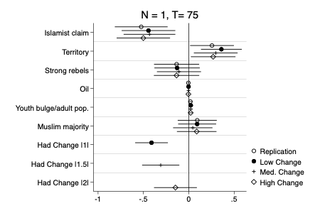

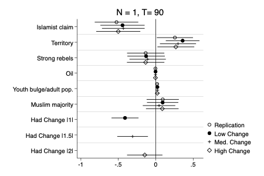

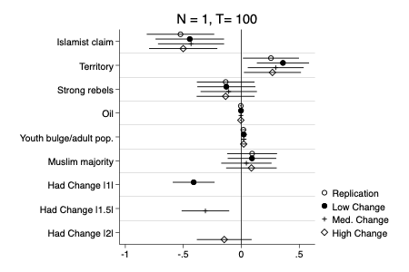

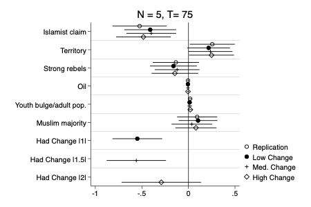

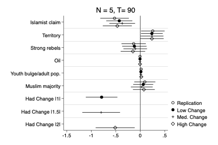

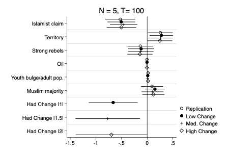

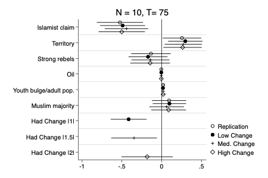

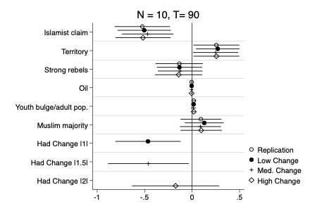

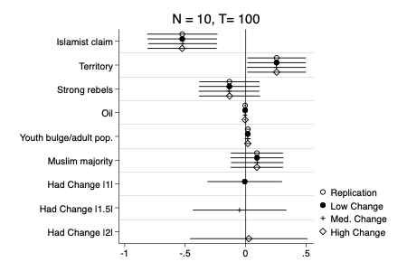